# 04_translate_point

## 04_translate_point

#### Question

1. A wallpaper was made by using repeated translations. I have depicted the translation of point $(-0.2, 0.77)$ in the direction $\theta=2.35$ (radians) by a distance of $r=2.5$.

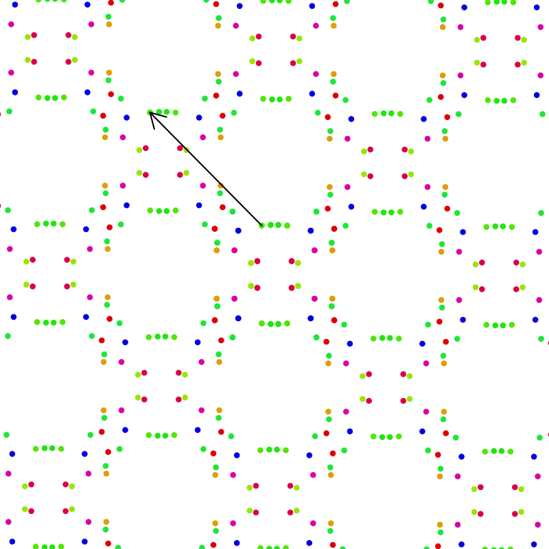

   What are the coordinates of the point at the end of the arrow (the result of the translation)?
   - The horizontal coordinate, $x'=$
   - The vertical coordinate, $y'=$

#### Question

2. A wallpaper was made by using repeated translations. I have depicted the translation of point $(-0.82, 0.48)$ in the direction $\theta=2.75$ (radians) by a distance of $r=2.8$.

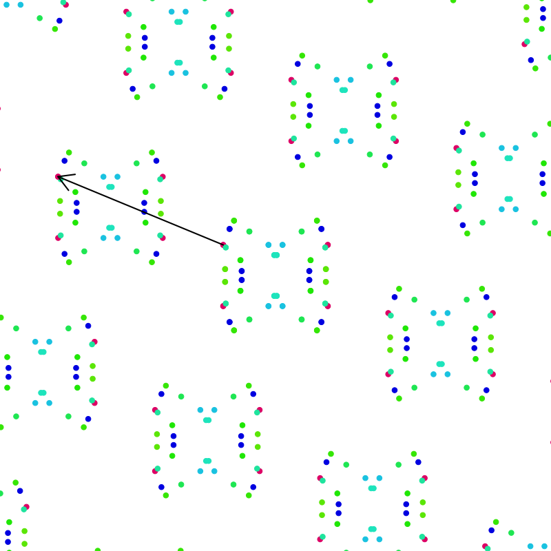

   What are the coordinates of the point at the end of the arrow (the result of the translation)?
   - The horizontal coordinate, $x'=$
   - The vertical coordinate, $y'=$

#### Question

3. A wallpaper was made by using repeated translations. I have depicted the translation of point $(0.71, 0.06)$ in the direction $\theta=0.4$ (radians) by a distance of $r=2.6$.

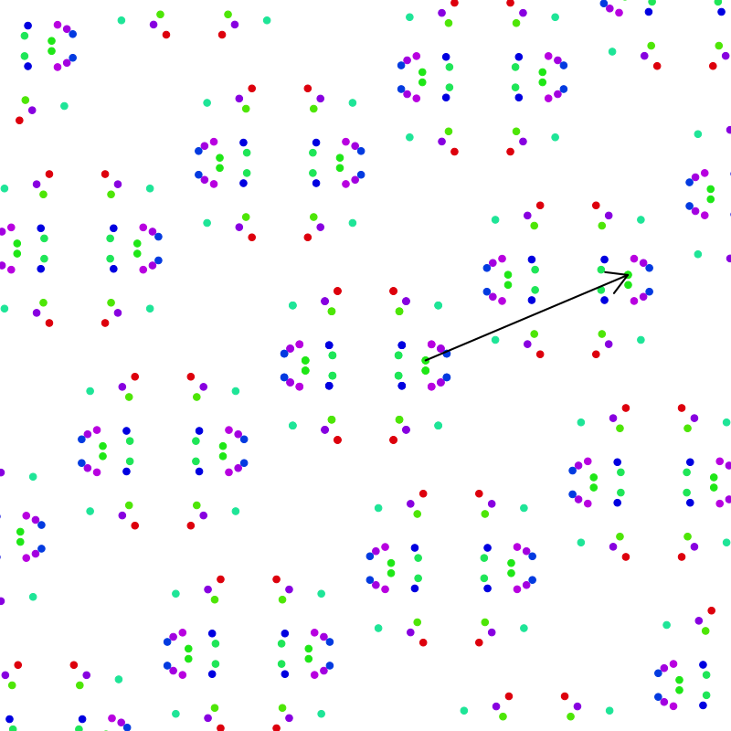

   What are the coordinates of the point at the end of the arrow (the result of the translation)?
   - The horizontal coordinate, $x'=$
   - The vertical coordinate, $y'=$

#### Question

4. A wallpaper was made by using repeated translations. I have depicted the translation of point $(0.43, -0.17)$ in the direction $\theta=3.65$ (radians) by a distance of $r=2.7$.

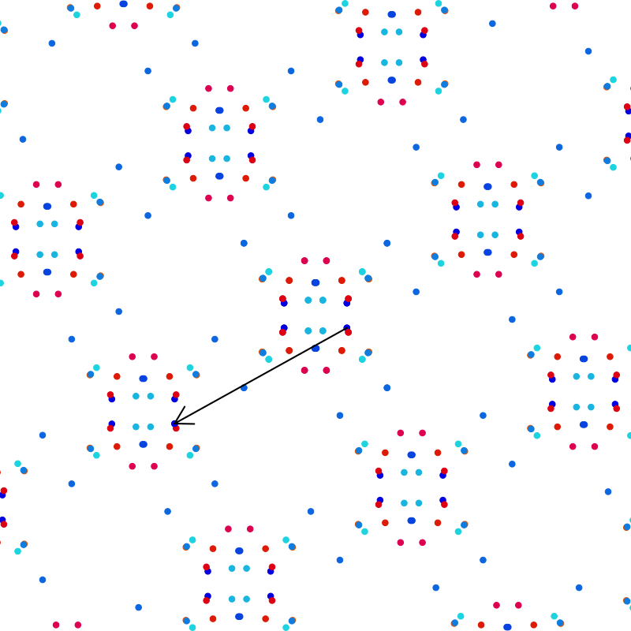

   What are the coordinates of the point at the end of the arrow (the result of the translation)?
   - The horizontal coordinate, $x'=$
   - The vertical coordinate, $y'=$

#### Question

5. A wallpaper was made by using repeated translations. I have depicted the translation of point $(0.33, -0.45)$ in the direction $\theta=5.61$ (radians) by a distance of $r=2.6$.

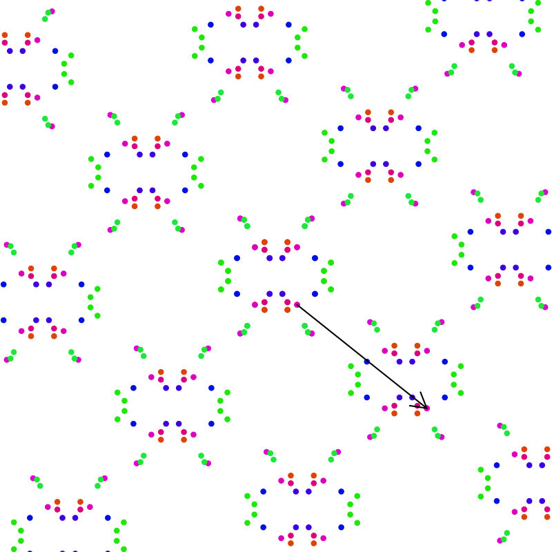

   What are the coordinates of the point at the end of the arrow (the result of the translation)?
   - The horizontal coordinate, $x'=$
   - The vertical coordinate, $y'=$

#### Question

6. A wallpaper was made by using repeated translations. I have depicted the translation of point $(0.59, -0.52)$ in the direction $\theta=0.54$ (radians) by a distance of $r=3$.

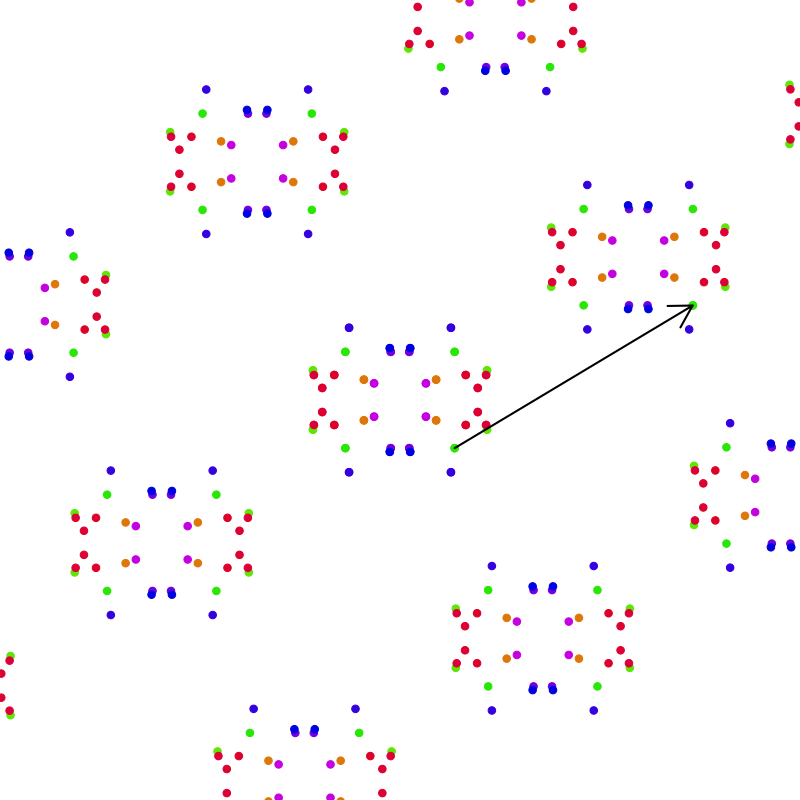

   What are the coordinates of the point at the end of the arrow (the result of the translation)?
   - The horizontal coordinate, $x'=$
   - The vertical coordinate, $y'=$

#### Question

7. A wallpaper was made by using repeated translations. I have depicted the translation of point $(-0.37, -0.91)$ in the direction $\theta=5.5$ (radians) by a distance of $r=2.1$.

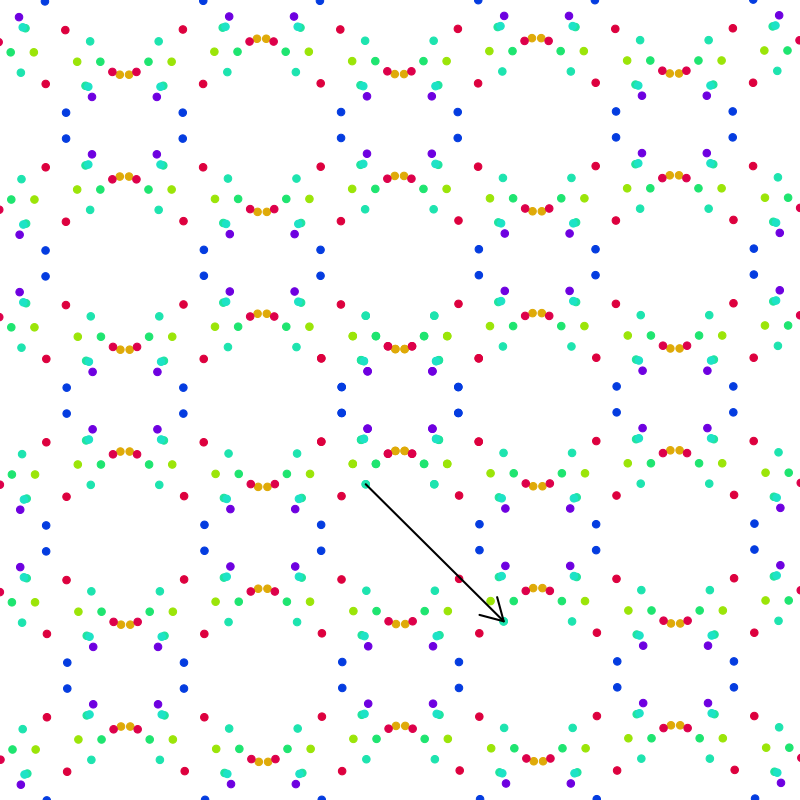

   What are the coordinates of the point at the end of the arrow (the result of the translation)?
   - The horizontal coordinate, $x'=$
   - The vertical coordinate, $y'=$

#### Question

8. A wallpaper was made by using repeated translations. I have depicted the translation of point $(0.75, 0.18)$ in the direction $\theta=5.51$ (radians) by a distance of $r=3$.

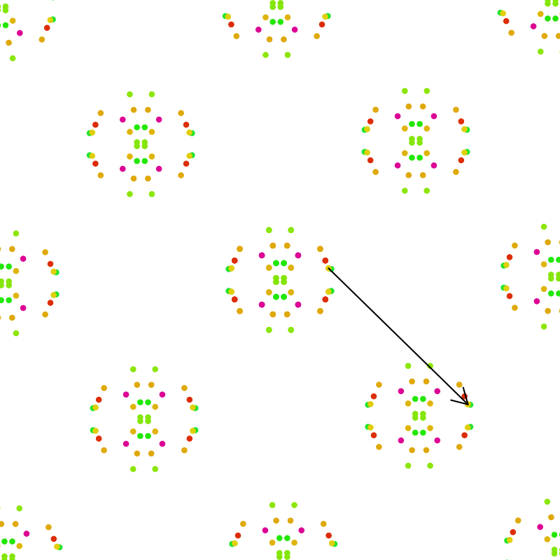

   What are the coordinates of the point at the end of the arrow (the result of the translation)?
   - The horizontal coordinate, $x'=$
   - The vertical coordinate, $y'=$